# yelp data analysis

## Data-Driven Insights into Restaurant Markets Using Hybrid Clustering and Regression on Yelp Data

This project presents a hybrid machine learning system that integrates both social computing and business analytics to provide data-driven insights for restaurant planning. By analyzing both restaurant characteristics and social signals, we demonstrate how social computing data can enhance business analytics.

Primary questions of exploration:

- Can we identify natural groupings of restaurant markets based on their characteristics?
- Can we predict how well a restaurant may perform in a particular area based on it's features (category, price range, sentiment,
- and cluster type)?
- What cities exhibit similar restaurant market patterns?

### Exploratory Data Analysis and Data Preparation

```python
import json, pandas as pd, numpy as np
import gc
import warnings
warnings.filterwarnings("ignore")
import plotly.express as px
import seaborn as sns
import matplotlib.pyplot as plt
%matplotlib inline

import os
# os.system('pip install --upgrade ipywidgets')
from tqdm import tqdm
from sklearn.cluster import KMeans

from sklearn.compose import ColumnTransformer
from sklearn.preprocessing import StandardScaler, OneHotEncoder
import pickle
from sklearn.ensemble import RandomForestRegressor
from sklearn.model_selection import train_test_split
from sklearn.metrics import r2_score, mean_absolute_error
from sklearn.tree import DecisionTreeClassifier
from sklearn.ensemble import GradientBoostingRegressor
from xgboost import XGBRegressor
from sklearn.metrics import r2_score, mean_absolute_error
import time
```

```python
def load_restaurants(path='../data/Yelp JSON/yelp_dataset/yelp_academic_dataset_business.json'):
    restaurants = []
    with open(path) as json_file:
        for line in tqdm(json_file, desc='Loading restaurants', colour='green'):
            b = json.loads(line)
            if b['categories'] and 'Restaurants' in b['categories'] and b['is_open'] == 1:
                restaurants.append({
                    'business_id': b['business_id'],
                    'name': b['name'],
                    'city': b['city'],
                    'state': b['state'],
                    'postal_code': b['postal_code'],
                    'latitude': b['latitude'],
                    'longitude': b['longitude'],
                    'stars': b['stars'],
                    'review_count': b['review_count'],
                    'categories': b['categories'],
                    'attributes': b['attributes'],
                    'hours': b['hours']
                })
    return pd.DataFrame(restaurants)

restaurants_df = load_restaurants()
print(f"Loaded {len(restaurants_df)} restaurants")
restaurants_df.head()
```

```
Loading restaurants: 150346it [00:00, 218703.45it/s]
```

```
Loaded 34987 restaurants
```

|  | business_id | name | city | state | postal_code | latitude | longitude | stars | review_count | categories | attributes | hours |
| --- | --- | --- | --- | --- | --- | --- | --- | --- | --- | --- | --- | --- |
| 0 | MTSW4McQd7CbVtyjqoe9mw | St Honore Pastries | Philadelphia | PA | 19107 | 39.955505 | -75.155564 | 4.0 | 80 | Restaurants, Food, Bubble Tea, Coffee & Tea, B... | {'RestaurantsDelivery': 'False', 'OutdoorSeati... | {'Monday': '7:0-20:0', 'Tuesday': '7:0-20:0', ... |
| 1 | CF33F8-E6oudUQ46HnavjQ | Sonic Drive-In | Ashland City | TN | 37015 | 36.269593 | -87.058943 | 2.0 | 6 | Burgers, Fast Food, Sandwiches, Food, Ice Crea... | {'BusinessParking': 'None', 'BusinessAcceptsCr... | {'Monday': '0:0-0:0', 'Tuesday': '6:0-22:0', '... |
| 2 | bBDDEgkFA1Otx9Lfe7BZUQ | Sonic Drive-In | Nashville | TN | 37207 | 36.208102 | -86.768170 | 1.5 | 10 | Ice Cream & Frozen Yogurt, Fast Food, Burgers,... | {'RestaurantsAttire': ''casual'', 'Restaurants... | {'Monday': '0:0-0:0', 'Tuesday': '6:0-21:0', '... |
| 3 | eEOYSgkmpB90uNA7lDOMRA | Vietnamese Food Truck | Tampa Bay | FL | 33602 | 27.955269 | -82.456320 | 4.0 | 10 | Vietnamese, Food, Restaurants, Food Trucks | {'Alcohol': ''none'', 'OutdoorSeating': 'None'... | {'Monday': '11:0-14:0', 'Tuesday': '11:0-14:0'... |
| 4 | il_Ro8jwPlHresjw9EGmBg | Denny's | Indianapolis | IN | 46227 | 39.637133 | -86.127217 | 2.5 | 28 | American (Traditional), Restaurants, Diners, B... | {'RestaurantsReservations': 'False', 'Restaura... | {'Monday': '6:0-22:0', 'Tuesday': '6:0-22:0', ... |

```python
# restaurants_df['price_range'] = restaurants_df['attributes'].apply(
#     lambda x: x.get('RestaurantsPriceRange2') if isinstance(x, dict) else None
# ).astype('float').fillna(2).astype(int)
#
# attr_cols = ['RestaurantsTakeOut', 'RestaurantsDelivery', 'OutdoorSeating',
#              'RestaurantsReservations', 'HasTV', 'Alcohol', 'WiFi', 'GoodForKids']
#
# for col in attr_cols:
#     restaurants_df[col] = restaurants_df['attributes'].apply(
#         lambda x: x.get(col) if isinstance(x, dict) else None
#     )
#     # convert the string values to boolean
#     restaurants_df[col] = restaurants_df[col].map({'True': True, 'False': False, 'None': False, None: False}).fillna(False)

# safer methods for lambda transformation
def extract_price(attrs):
    if not attrs or not isinstance(attrs, dict):
        return None
    val = attrs.get('RestaurantsPriceRange2')
    if val in (None, 'None', ''):
        return None
    try:
        return int(val)
    except (ValueError, TypeError):
        return None

def parse_bool(attrs, key, default=False):
    if not attrs or not isinstance(attrs, dict):
        return default
    val = attrs.get(key)
    if val in (True, 'True', "u'True'", "'True'", 'Yes'):
        return True
    if val in (False, 'False', "u'False'", "'False'", 'No', 'None', None):
        return False
    return default

# apply them cleanly
restaurants_df['price_range'] = restaurants_df['attributes'].apply(extract_price).fillna(2).astype(int)

bool_attrs = [
    'RestaurantsTakeOut', 'RestaurantsDelivery', 'OutdoorSeating',
    'RestaurantsReservations', 'HasTV', 'WiFi', 'GoodForKids'
]

for attr in bool_attrs:
    restaurants_df[attr] = restaurants_df['attributes'].apply(lambda x: parse_bool(x, attr))
```

```python
def load_checkin_counts(checkin_path='../data/Yelp JSON/yelp_dataset/yelp_academic_dataset_checkin.json'):
    counts = {}

    with open(checkin_path, encoding='utf-8') as f:
        for line in tqdm(f, total=131930, desc="Processing check-ins"):
            obj = json.loads(line)
            bid = obj['business_id']
            # count the number of checkins
            count = len(obj['date'].split(',')) if obj['date'].strip() else 0
            counts[bid] = count

    return pd.DataFrame(list(counts.items()), columns=['business_id', 'checkin_count'])

checkin_df = load_checkin_counts()

# previous fix: drop any existing checkin_count column before merging
if 'checkin_count' in restaurants_df.columns:
    restaurants_df = restaurants_df.drop(columns=['checkin_count'])
if 'checkin_count_x' in restaurants_df.columns:
    restaurants_df = restaurants_df.drop(columns=['checkin_count_x'])
if 'checkin_count_y' in restaurants_df.columns:
    restaurants_df = restaurants_df.drop(columns=['checkin_count_y'])

restaurants_df = restaurants_df.merge(checkin_df, on='business_id', how='left')

# handle missing with 0 and make integer
restaurants_df['checkin_count'] = restaurants_df['checkin_count'].fillna(0).astype(int)

print(f"{restaurants_df['checkin_count'].sum():,} total check-ins across all restaurants")
print(f"Restaurants with over 100 check-ins: {(restaurants_df['checkin_count'] >= 100).sum():,}")
restaurants_df[['name', 'city', 'checkin_count']].sort_values('checkin_count', ascending=False).head(10)
```

```
6,757,093 total check-ins across all restaurants
Restaurants with over 100 check-ins: 12,797
```

|  | name | city | checkin_count |
| --- | --- | --- | --- |
| 7882 | Café Du Monde | New Orleans | 40109 |
| 7267 | Royal House | New Orleans | 28927 |
| 26163 | Oceana Grill | New Orleans | 21542 |
| 33302 | Reading Terminal Market | Philadelphia | 18615 |
| 26439 | Acme Oyster House | New Orleans | 15205 |
| 12193 | The Jug Handle Inn | Cinnaminson | 13244 |
| 34209 | Ruby Slipper - New Orleans | New Orleans | 10209 |
| 12281 | Pat O'Brien’s | New Orleans | 10135 |
| 9850 | Gumbo Shop | New Orleans | 9574 |
| 29074 | The Original Pierre Maspero's | New Orleans | 9464 |

```python
cuisine_keywords = [
    'Mexican', 'Italian', 'Chinese', 'Japanese', 'Indian', 'Thai', 'French',
    'American', 'Mediterranean', 'Vietnamese', 'Korean', 'Greek', 'Cajun',
    'Spanish', 'Middle Eastern', 'Caribbean', 'German', 'Irish', 'Pizza'
]

def get_main_cuisine(categories):
    if not categories:
        return 'Other'
    cats = [c.strip() for c in categories.split(',')]
    for cuisine in cuisine_keywords:
        if cuisine in cats:
            return cuisine
    return 'Other'

restaurants_df['cuisine'] = restaurants_df['categories'].apply(get_main_cuisine)
```

```python
def kmeans_market_density(df, n_clusters=1200, new_col='market_cluster_density'):
    print(f"creating {n_clusters} micro markets using KMeans on location")

    coords = df[['longitude', 'latitude']].values
    kmeans = KMeans(n_clusters=n_clusters, random_state=42, n_init=10)
    df['market_cluster'] = kmeans.fit_predict(coords)

    cluster_sizes = df['market_cluster'].value_counts()
    df[new_col] = df['market_cluster'].map(cluster_sizes)

    df[new_col] = df[new_col] - 1

    print(f"Most crowded micro market has {df[new_col].max() + 1} restaurants")
    return df

restaurants_df = kmeans_market_density(restaurants_df, new_col='cluster_density')
```

```
creating 1200 micro markets using KMeans on location
Most crowded micro market has 356 restaurants
```

Previous considerations included groupings in 2km ranges. With KMeans, we are able to discover 1200 natural micro markets across North America. The `cluster_density` will be a strong feature in later analysis.

```python
# success_score feature, score = percentile rank within each city
restaurants_df['log_reviews'] = np.log1p(restaurants_df['review_count'])

restaurants_df['success_score'] = restaurants_df.groupby('city')['log_reviews']\
    .transform(lambda x: x.rank(pct=True) * 100)
```

```python
"""
Updated (static) plots in final cell output, there were too many issues displaying Plotly plots in HTML exports and github.
"""
# fig1 = px.scatter_mapbox(
#     restaurants_df.sample(min(8000, len(restaurants_df))),
#     lat="latitude", lon="longitude",
#     color="stars", size="review_count",
#     hover_name="name", hover_data=["city", "cuisine"],
#     title="Yelp Restaurants: Size = Popularity, Color = Rating",
#     zoom=3, height=600
# )
# fig1.update_layout(mapbox_style="carto-positron")
# fig1.show()
#
# fig2 = px.bar(restaurants_df['city'].value_counts().head(15),
#               title="Top 15 cities by restaurant count",
#               labels={'value': 'Number of Restaurants', 'index': 'City'},
#               color=restaurants_df['city'].value_counts().head(15).values,
#               color_continuous_scale="Blues")
# fig2.update_xaxes(tickangle=45)
# fig2.show()
#
# fig3 = px.histogram(restaurants_df, x='success_score', nbins=50,
#                     title="Success score distribution (by percentile within city)",
#                     color_discrete_sequence=['#636EFA'])
# fig3.update_layout(bargap=0.1)
# fig3.show()
#
# fig4 = px.scatter(restaurants_df.sample(10000),
#                   x='cluster_density', y='success_score',
#                   color='price_range', size='review_count',
#                   hover_data=['name', 'city', 'cuisine'],
#                   title="Market Hotspot Density vs Success Score",
#                   labels={'cluster_density': 'Competitors in Natural Micro-Market',
#                           'success_score': 'Success Score (percentile)'},
#                   color_continuous_scale="Portland")
# fig4.show()

underserved = restaurants_df[restaurants_df['success_score'] < 30]
print(f"Underserved locations (bottom 30% in their city): {len(underserved):,}")
```

```
Underserved locations (bottom 30% in their city): 10,127
```

```python
# save to central csv
restaurants_df.to_csv('yelp_restaurants_final.csv', index=False)
```

```python
# preprocessing pipeline
feature_cols = ['latitude', 'longitude', 'price_range', 'checkin_count',
                'cluster_density', 'cuisine', 'city']

X = restaurants_df[feature_cols]
y = restaurants_df['success_score']

preprocessor = ColumnTransformer([
    ('num', StandardScaler(), ['latitude', 'longitude', 'price_range',
                                'checkin_count', 'cluster_density']),
    ('cat', OneHotEncoder(handle_unknown='ignore', sparse_output=False),
     ['cuisine', 'city'])
], remainder='drop')

X_final = preprocessor.fit_transform(X)
print(f"preprocessed matrix shape: {X_final.shape}")
pickle.dump(preprocessor, open('../preprocessor.pkl', 'wb'))
print("preprocessor.pkl saved!")
```

```
preprocessed matrix shape: (34987, 869)
preprocessor.pkl saved!
```

```python
kmeans_rest = KMeans(n_clusters=12, random_state=42, n_init=10)
restaurants_df['restaurant_cluster'] = kmeans_rest.fit_predict(X_final)
pickle.dump(kmeans_rest, open('../kmeans_restaurants.pkl', 'wb'))

# city level clustering
city_agg = restaurants_df.groupby('city').agg({
    'stars': 'mean',
    'price_range': 'mean',
    'cluster_density': 'mean',
    'checkin_count': 'mean',
    'success_score': 'mean',
    'review_count': 'count'
}).reset_index()

city_numeric_correct_order = pd.DataFrame({
    'latitude': 0,                          # dummy
    'longitude': 0,                         # dummy
    'price_range': city_agg['price_range'],
    'checkin_count': city_agg['checkin_count'],
    'cluster_density': city_agg['cluster_density']
})

scaler = preprocessor.named_transformers_['num']
city_scaled = scaler.transform(city_numeric_correct_order)

kmeans_city = KMeans(n_clusters=6, random_state=42, n_init=10)
city_agg['city_cluster'] = kmeans_city.fit_predict(city_scaled)

restaurants_df = restaurants_df.merge(city_agg[['city', 'city_cluster']], on='city', how='left')
pickle.dump(kmeans_city, open('../kmeans_cities.pkl', 'wb'))

fig = px.bar(
    x=range(12),
    y=restaurants_df['restaurant_cluster'].value_counts().sort_index(),
    title="Restaurant Cluster Distributions",
    labels={'x': 'Cluster ID', 'y': 'Number of Restaurants'},
    color=range(12),
    color_continuous_scale="Viridis"
)
fig.update_layout(showlegend=False, height=500)
fig.show()

# print(city_agg[['city', 'city_cluster']].sort_values('city_cluster').head(20))
```

[output not shown]

```python
print("discovered city market types:\n")
print(city_agg.groupby('city_cluster').agg({
    'city': 'count',
    'review_count': 'mean',
    'cluster_density': 'mean',
    'success_score': 'mean'
}).round(2))

print("\nTop cities in each cluster:")
for i in range(6):
    top = city_agg[city_agg['city_cluster'] == i][['city', 'review_count']].sort_values('review_count', ascending=False).head(5)
    print(f"\nCluster {i} (n={len(city_agg[city_agg['city_cluster']==i])} cities):")
    print(top.to_string(index=False))
```

```
discovered city market types:

              city  review_count  cluster_density  success_score
city_cluster
0              131          2.20            24.02          90.30
1               92        159.95            51.43          63.17
2              232         13.15            23.53          83.58
3              372         32.24            23.29          55.71
4                6        820.00           178.00          83.34
5               13          1.46            18.00          89.74

Top cities in each cluster:

Cluster 0 (n=131 cities):
           city  review_count
      Hazelwood            25
       Lawrence            15
Sun City Center            14
        Cahokia            12
          Salem             9

Cluster 1 (n=92 cities):
        city  review_count
       Tampa          1964
Indianapolis          1904
   Nashville          1681
      Tucson          1639
 Saint Louis           957

Cluster 2 (n=232 cities):
          city  review_count
      Edmonton          1553
 Sherwood Park           107
         Wayne            67
       Malvern            66
Kennett Square            63

Cluster 3 (n=372 cities):
       city  review_count
 Wilmington           437
 Clearwater           436
   Meridian           236
      Largo           206
Cherry Hill           193

Cluster 4 (n=6 cities):
        city  review_count
Philadelphia          3525
 New Orleans          1391
    Downtown             1
 NEW ORLEANS             1
St Petersurg             1

Cluster 5 (n=13 cities):
         city  review_count
   Mendenhall             3
Birchrunville             2
     Fairview             2
     Holicong             2
   Unionville             2
```

The city level KMeans clustering reveals that there are 6 distinct restaurant market types.

This shows that location type is a strong feature to predict restaurant success.

```python
from sklearn.tree import DecisionTreeRegressor

X_train, X_test, y_train, y_test = train_test_split(
    X_final, y, test_size=0.2, random_state=42
)

results = []

print("Decision Tree")
start = time.time()

dt = DecisionTreeRegressor(max_depth=18, random_state=42)
dt.fit(X_train, y_train)
dt_pred = dt.predict(X_test)
results.append({
    'Model': 'Decision Tree',
    'R2': round(r2_score(y_test, dt_pred), 4),
    'Mean absolute error': round(mean_absolute_error(y_test, dt_pred), 2),
    'Time in seconds': round(time.time() - start, 1)
})

print("Gradient Boosting")
start = time.time()
gb = GradientBoostingRegressor(n_estimators=300, max_depth=6, learning_rate=0.1, random_state=42)
gb.fit(X_train, y_train)
gb_pred = gb.predict(X_test)
results.append({
    'Model': 'Gradient Boosting',
    'R2': round(r2_score(y_test, gb_pred), 4),
    'Mean absolute error': round(mean_absolute_error(y_test, gb_pred), 2),
    'Time in seconds': round(time.time() - start, 1)
})

print("Random Forest")
start = time.time()
rf = RandomForestRegressor(n_estimators=400, max_depth=22, n_jobs=-1, random_state=42)
rf.fit(X_train, y_train)
rf_pred = rf.predict(X_test)
results.append({
    'Model': 'Random Forest (Deployed)',
    'R2': round(r2_score(y_test, rf_pred), 4),
    'Mean absolute error': round(mean_absolute_error(y_test, rf_pred), 2),
    'Time in seconds': round(time.time() - start, 1)
})

comparison = pd.DataFrame(results).sort_values('R2', ascending=False)
print("*" * 20 + " FINAL MODEL COMPARISON " + "*" * 20)
print(comparison.to_string(index=False))

# save final model
pickle.dump(rf, open('../final_model.pkl', 'wb'))
pickle.dump(preprocessor, open('../preprocessor.pkl', 'wb'))
print("\nfinal_model.pkl + preprocessor.pkl saved")
```

```
Decision Tree
Gradient Boosting
Random Forest
******************** FINAL MODEL COMPARISON ********************
                   Model     R2  Mean absolute error  Time in seconds
       Gradient Boosting 0.6669                12.49            166.4
Random Forest (Deployed) 0.6445                12.74             31.4
           Decision Tree 0.5251                14.72              0.5

final_model.pkl + preprocessor.pkl saved
```

Static generation of the plots were needed, as Plotly figures were not appearing in the HTML and notebook file in Github.

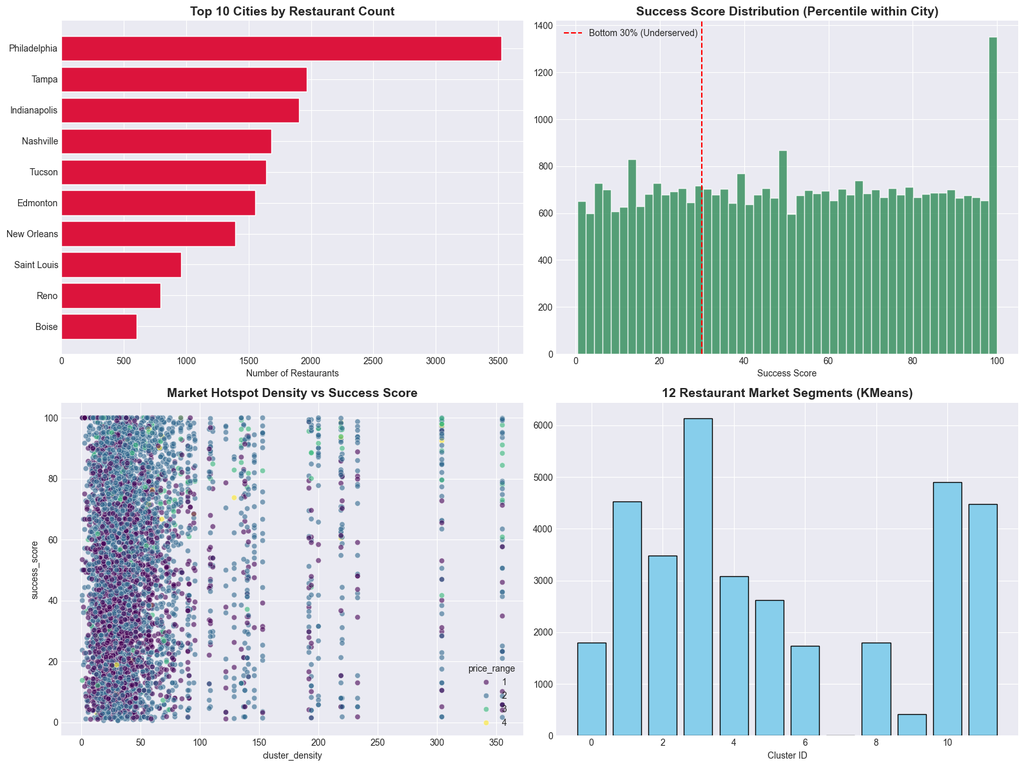

```python
plt.style.use('seaborn-v0_8-darkgrid')
os.makedirs("static_plots", exist_ok=True)

fig, axes = plt.subplots(2, 2, figsize=(16, 12))

top_cities = restaurants_df['city'].value_counts().head(10)
axes[0,0].barh(top_cities.index[::-1], top_cities.values[::-1], color='crimson')
axes[0,0].set_title("Top 10 Cities by Restaurant Count", fontsize=14, fontweight='bold')
axes[0,0].set_xlabel("Number of Restaurants")

axes[0,1].hist(restaurants_df['success_score'], bins=50, color='seagreen', alpha=0.8)
axes[0,1].set_title("Success Score Distribution (Percentile within City)", fontsize=14, fontweight='bold')
axes[0,1].set_xlabel("Success Score")
axes[0,1].axvline(30, color='red', linestyle='--', label="Bottom 30% (Underserved)")
axes[0,1].legend()

sns.scatterplot(data=restaurants_df.sample(5000), x='cluster_density', y='success_score',
                hue='price_range', palette='viridis', ax=axes[1,0], alpha=0.6)
axes[1,0].set_title("Market Hotspot Density vs Success Score", fontsize=14, fontweight='bold')

cluster_counts = restaurants_df['restaurant_cluster'].value_counts().sort_index()
axes[1,1].bar(cluster_counts.index, cluster_counts.values, color='skyblue', edgecolor='black')
axes[1,1].set_title("12 Restaurant Market Segments (KMeans)", fontsize=14, fontweight='bold')
axes[1,1].set_xlabel("Cluster ID")

plt.tight_layout()
plt.savefig("static_plots/all_key_insights.png", dpi=300, bbox_inches='tight')
plt.show()
```